# Labo 5

#### Contraste de normalidad Shapiro-Wilk para cada variable en cada tipo de billete

```
## # A tibble: 12 x 3
## # Groups:   Status [2]
##    Status      variable p_value_Shapiro.test
##    <fct>       <fct>                   <dbl>
##  1 counterfeit Length                0.00290
##  2 counterfeit Left                  0.0237
##  3 counterfeit Right                 0.0168
##  4 counterfeit Bottom                0.0112
##  5 counterfeit Top                   0.0491
##  6 counterfeit Diagonal              0.00003
##  7 genuine     Length                0.257
##  8 genuine     Left                  0.00825
##  9 genuine     Right                 0.0117
## 10 genuine     Bottom                0.0403
## 11 genuine     Top                   0.0498
## 12 genuine     Diagonal              0.0033
```

#### Normalidad multivariante y otras pruebas

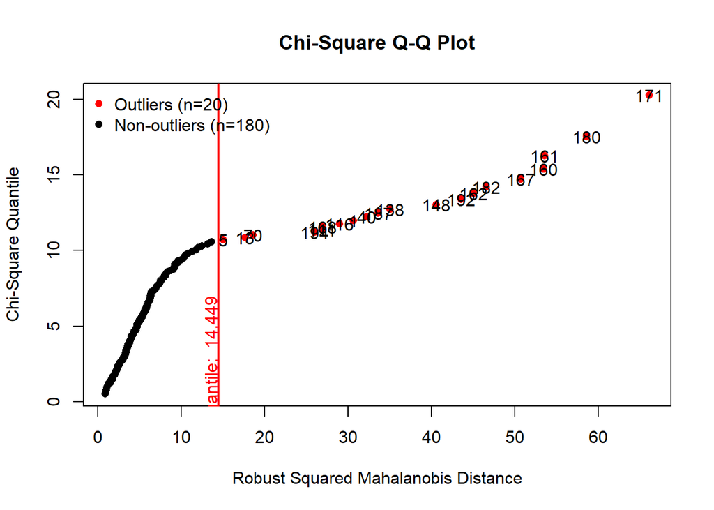

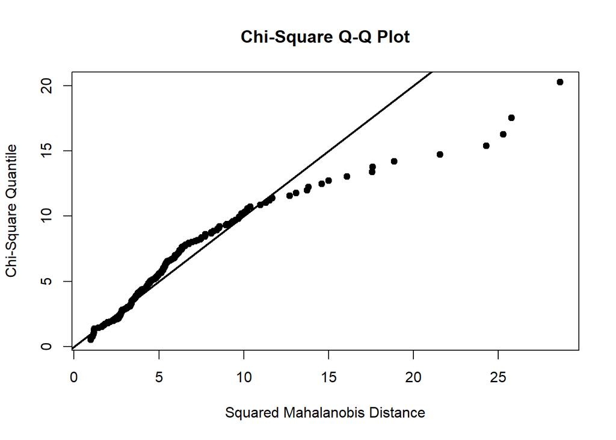

```
##      Test        H      p value MVN
## 1 Royston 67.03927 5.820549e-13  NO
```

```
##            Test       HZ p value MVN
## 1 Henze-Zirkler 1.780591       0  NO
```

#### Test de homogeneidad

```
##
##  Box's M-test for Homogeneity of Covariance Matrices
##
## data:  banknote[, -1]
## Chi-Sq (approx.) = 121.9, df = 21, p-value = 3.198e-16
```

## Partición del archivo de datos

Pera evaluar la regla de decisión, se suele particionar el archivo de datos en entramiento y validación. Esto es un procedimiento típico de los análisis supervisados, y también en la minería de datos.

```r
training_sample <- sample(c(TRUE, FALSE), nrow(iris), replace = T, prob = c(0.6,0.4))

train <- iris[training_sample, ]
test <- iris[!training_sample, ]
```

Dimensiones del set de entrenamiento

```
## [1] 93  5
```

Dimensiones del set de validación

```
## [1] 57  5
```

## Estimación del lda y qda

### Estimación del lda

```r
lda.iris <- lda(Species ~ ., train)
lda.iris
```

```
## Call:
## lda(Species ~ ., data = train)
##
## Prior probabilities of groups:
##     setosa versicolor  virginica
##  0.3333333  0.3118280  0.3548387
##
## Group means:
##            Sepal.Length Sepal.Width Petal.Length Petal.Width
## setosa         4.967742    3.416129     1.438710   0.2258065
## versicolor     5.889655    2.724138     4.210345   1.3068966
## virginica      6.566667    2.987879     5.542424   2.0272727
##
## Coefficients of linear discriminants:
##                     LD1        LD2
## Sepal.Length  0.7660186 -0.2647834
## Sepal.Width   1.5182031  2.5533252
## Petal.Length -2.0245925 -0.6093273
## Petal.Width  -2.9188008  2.3927265
##
## Proportion of trace:
##    LD1    LD2
## 0.9883 0.0117
```

```r
names(lda.iris)
```

```
##  [1] "prior"   "counts"  "means"   "scaling" "lev"     "svd"     "N"
##  [8] "call"    "terms"   "xlevels"
```

Enfoquemos en la salida, la parte de los coeficientes (podemos verlo vediante el “scaling”)

¿Cuál sería entonces las ecuaciones de ambas reglas?

LD1 ? LD2 ?

### Estimación del qda

```r
qda.iris <- qda(Species ~ Sepal.Length + Sepal.Width + Petal.Length + Petal.Width, train)
qda.iris
```

```
## Call:
## qda(Species ~ Sepal.Length + Sepal.Width + Petal.Length + Petal.Width,
##     data = train)
##
## Prior probabilities of groups:
##     setosa versicolor  virginica
##  0.3333333  0.3118280  0.3548387
##
## Group means:
##            Sepal.Length Sepal.Width Petal.Length Petal.Width
## setosa         4.967742    3.416129     1.438710   0.2258065
## versicolor     5.889655    2.724138     4.210345   1.3068966
## virginica      6.566667    2.987879     5.542424   2.0272727
```

Analisando la función qda, no se programó la ecuación del qda…

## Análisis de Regla de discriminación

Una forma de ver la efectividad de las reglas de separarción en poner en un plano 2D los casos con sus respectivas reglas si hubiese 2.

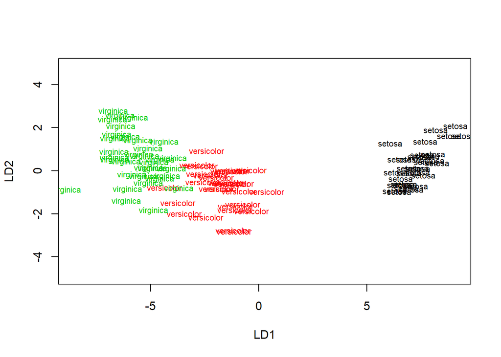

```r
plot(lda.iris, col = as.integer(train$Species))
```

También se puede corroborar mediante el análisis de la posición y variabilidad por categoría de clasificación, en cada regla. El caso de la RD1:

```r
lda.iris <- lda(Species ~ ., train)
lda.iris
```

```
## Call:
## lda(Species ~ ., data = train)
##
## Prior probabilities of groups:
##     setosa versicolor  virginica
##  0.3333333  0.3118280  0.3548387
##
## Group means:
##            Sepal.Length Sepal.Width Petal.Length Petal.Width
## setosa         4.967742    3.416129     1.438710   0.2258065
## versicolor     5.889655    2.724138     4.210345   1.3068966
## virginica      6.566667    2.987879     5.542424   2.0272727
##
## Coefficients of linear discriminants:
##                     LD1        LD2
## Sepal.Length  0.7660186 -0.2647834
## Sepal.Width   1.5182031  2.5533252
## Petal.Length -2.0245925 -0.6093273
## Petal.Width  -2.9188008  2.3927265
##
## Proportion of trace:
##    LD1    LD2
## 0.9883 0.0117
```

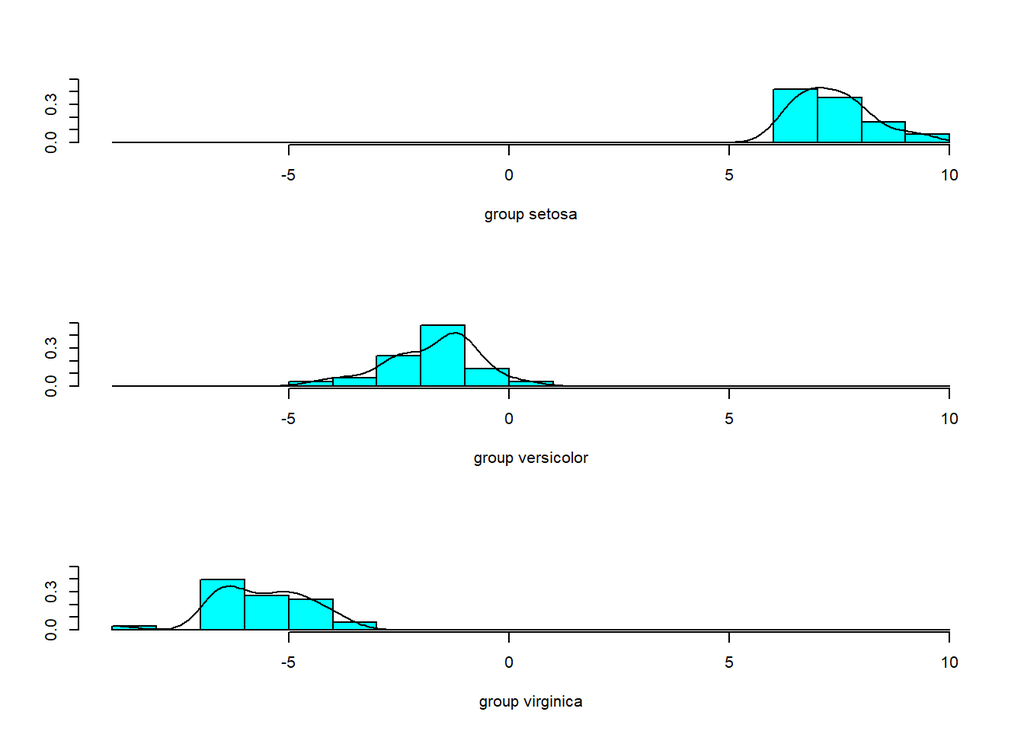

```r
plot(lda.iris, dimen = 1, type = "b")
```

Tengo un error para la 2nd dimensión… creo que debe ser porque explica muy poco.

```r
#plot(lda.iris, dimen = 2, type = "both")
```

Otra forma de ver la efectividad de las reglas es mediante la proyección de la regla y sus inviduos para ciertas variables.

Veamos que tanto separa o discrimina la primera regla

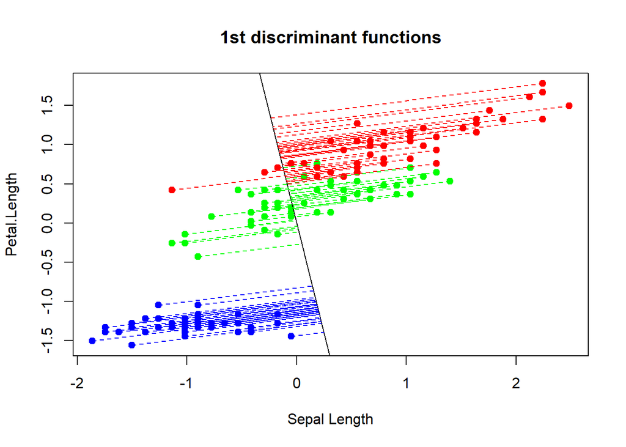

Y para la 2nda regla:

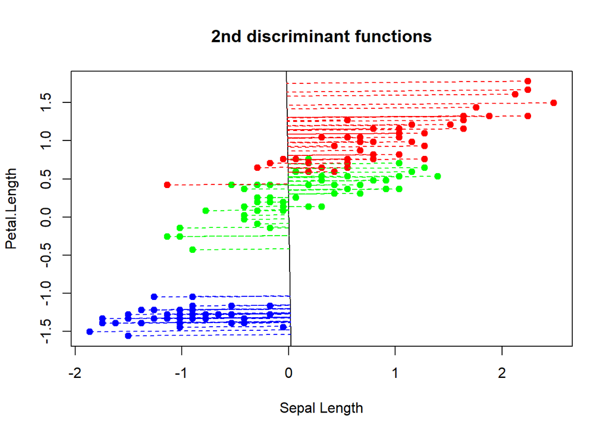

¿Qué podemos concluir?

## Los gráficos de partición y las proyecciones

### Particiones clásiscas con partimat

El uso de la función partimat del paquete klaR proporciona una forma alternativa de trazar las funciones discriminantes lineales. partimat emite una serie de gráficos para cada combinación de dos variables. Piense en cada gráfico como una vista diferente de los mismos datos. Las regiones coloreadas delinean cada área de clasificación. Se predice que cualquier observación que caiga dentro de una región será de una clase específica. Cada gráfico también incluye la tasa de error aparente para esa vista de los datos.

Partición lineal

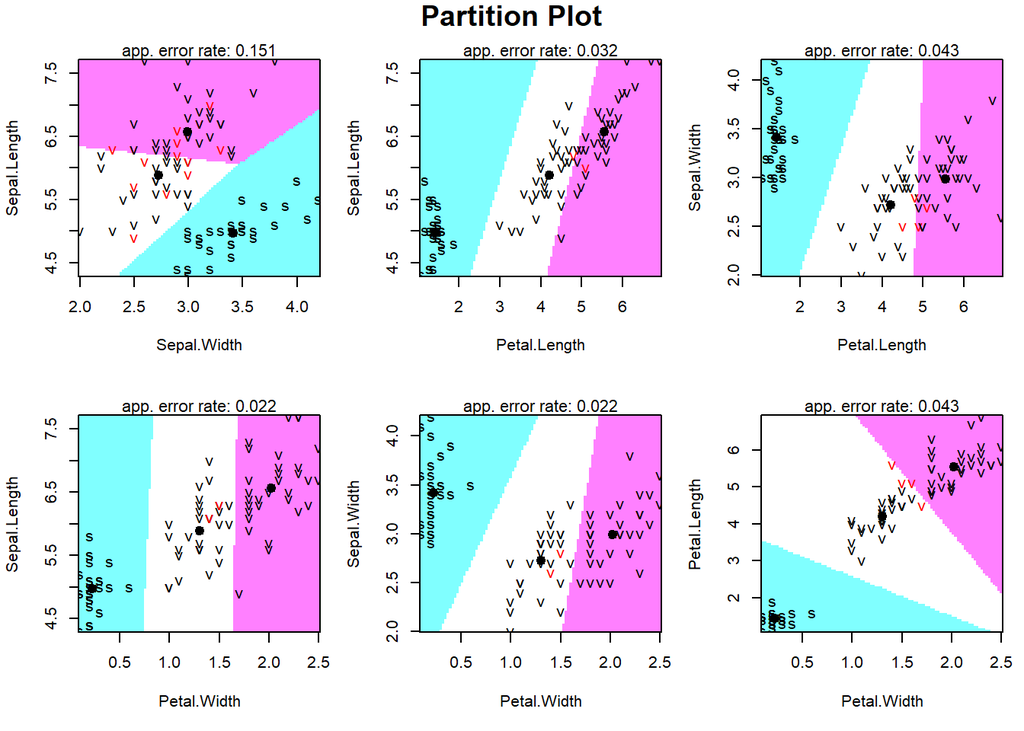

Partición cuadrática

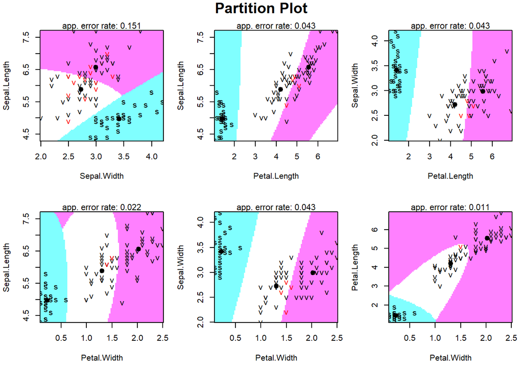

### Particiones partimat cambiando el color

La función partimat() del paquete klar permite representar los límites de clasificación de un modelo discriminante lineal o cuadrático para cada par de predictores. Cada color representa una región de clasificación acorde al modelo, se muestra el centroide de cada región y el valor real de las observaciones.

Partición lineal

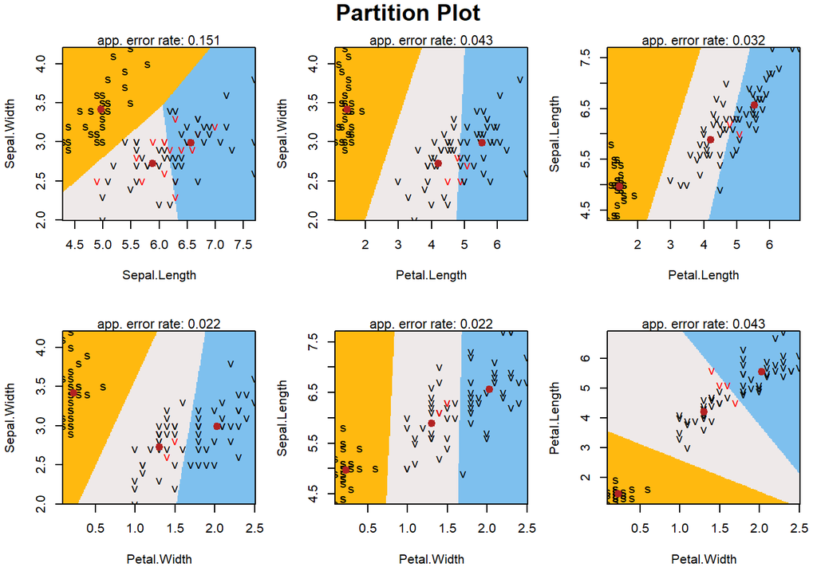

Partición cuadrática

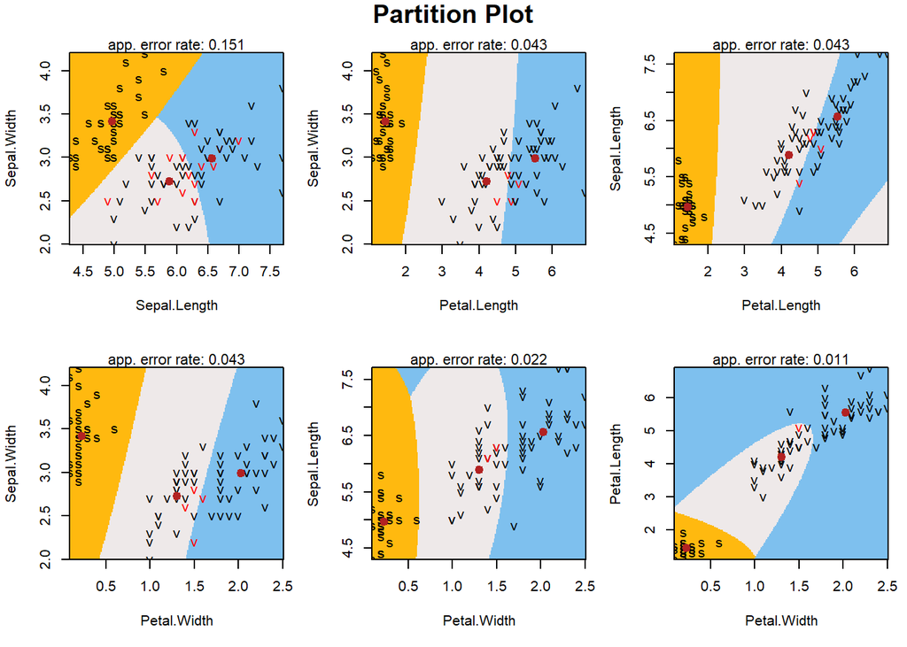

### Proyección del modelo: variables y predicciones

Podemos verificar la calidad del análisis mediante las proyeccioes de las variables y las predicciones.

Variables: podemos ver los resultados del modelo de la separación de los casos en los variables.

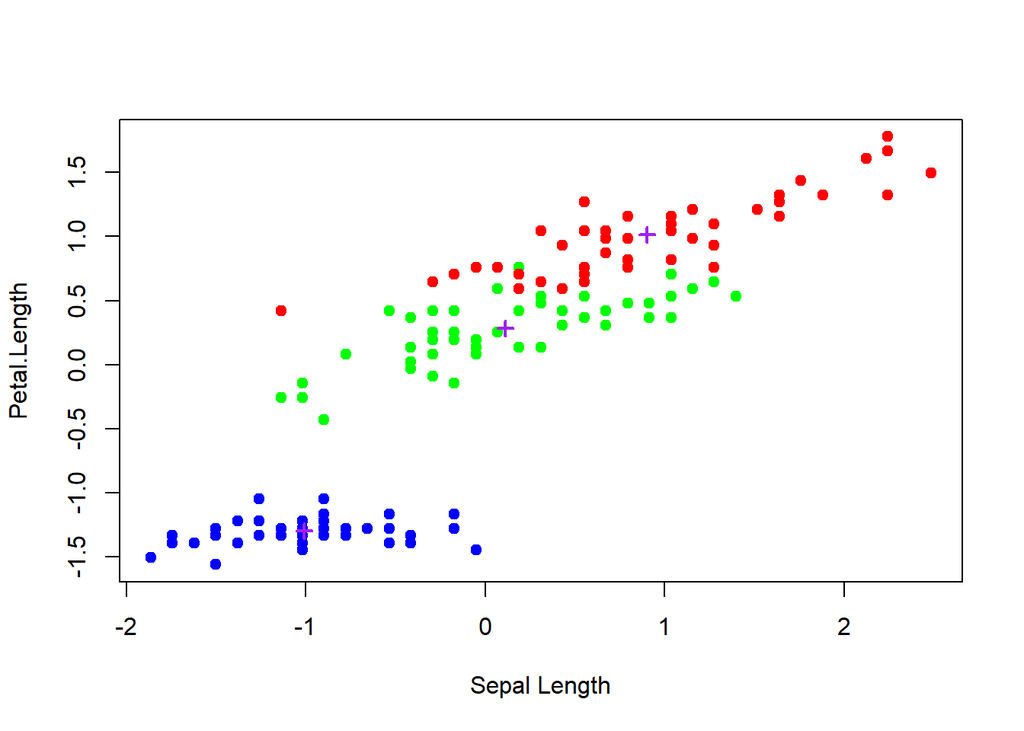

¿Qué podemos decir?

Predicciones.

Podemos para los valores de las reglas verificar si los individuos se están o no separando o aglomerando en cierto parte.

LD1: ¿qué podemos decir?

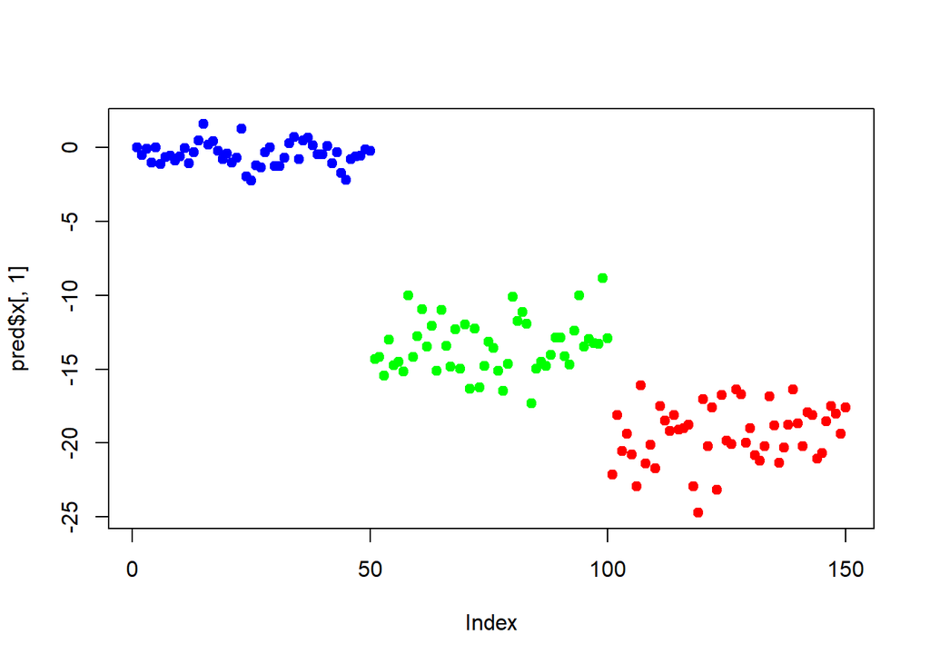

LD2: ¿qué podemos decir?

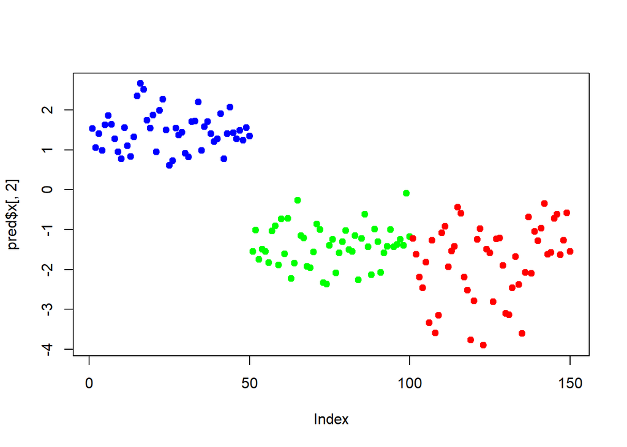

## Las tablas de confusión

### Set de entrenamiento

#### LDA

```
##
##              setosa versicolor virginica
##   setosa         31          0         0
##   versicolor      0         28         1
##   virginica       0          1        32
```

–> Recomendable tenerlo mejor en %

¿Qué podemos concluir del modelo para el entrenamiento?

#### QDA

```
##
##              setosa versicolor virginica
##   setosa         31          0         0
##   versicolor      0         28         1
##   virginica       0          1        32
```

–> Recomendable tenerlo mejor en %

¿Qué podemos concluir del modelo para el entrenamiento? Y comparando LDA y QDA

### Set de validación

#### LDA

```
##
##              setosa versicolor virginica
##   setosa         19          0         0
##   versicolor      0         20         0
##   virginica       0          1        17
```

–> Recomendable tenerlo mejor en %

#### QDA

```
##
##              setosa versicolor virginica
##   setosa         19          0         0
##   versicolor      0         20         0
##   virginica       0          1        17
```

–> Recomendable tenerlo mejor en %